# Defossez et al OPLS

```r
library(glue)
```

# Species level averages

Species-level averages are provided on Dryad.

```r
cardamine <-
  read_delim(here("data", "Defossez et al.", "all traits averages.csv"), delim = ";") %>%
  clean_names()
cardamine
```

| spp | alt | light | moisture | ph | nutrients | avg_alt | fd_temperature | fd_moisture | fd_radiation | wight | sla | dmage | height | photosy | toughness | pieris | spod | c_n | gls_c | gls_ja | gls_ja_c | nb_peaks | voc_c | voc_ja | vocs_ja_c |
| --- | --- | --- | --- | --- | --- | --- | --- | --- | --- | --- | --- | --- | --- | --- | --- | --- | --- | --- | --- | --- | --- | --- | --- | --- | --- |
| C_alpina | 1.0 | 4 | 4.0 | 2 | 2 | 2450.2982 | 681.2931 | 678.775862 | 24673.19 | 158.6250 | 16.23765 | 3.437500 | 4.56250 | 38.89583 | 45.00000 | NA | NA | 10.583035 | 68.176942 | 46.6989620 | -21.47798020 | 13 | 0.1533958 | 0.2109932 | 0.05759749 |
| C_amara | 2.0 | 4 | 5.0 | 3 | 3 | 954.1897 | 2226.8375 | -147.243750 | 26627.30 | 269.8750 | 14.30764 | 8.750000 | 26.12500 | 28.75208 | 61.62500 | 2.751619 | 0.2017750 | 8.729169 | 44.600563 | 44.5132426 | -0.08732079 | 7 | 0.2874441 | 4.0576643 | 3.77022025 |
| C_asarifolia | 2.0 | 4 | 5.0 | 2 | 3 | 998.8889 | 2141.5000 | -264.611111 | 26309.28 | NA | NA | NA | NA | NA | NA | NA | NA | NA | 44.121381 | NA | NA | NA | 0.2578886 | 0.8046457 | 0.54675711 |
| C_bulbifera | 3.5 | 2 | 3.5 | 3 | 4 | 581.0000 | 2506.1000 | 0.450000 | 27535.20 | 515.5000 | 55.53945 | 37.500000 | 36.55000 | 33.62333 | 42.26667 | NA | NA | 10.283131 | 27.569590 | 47.7936768 | 20.22408679 | 8 | 0.4091443 | 3.2023735 | 2.79322925 |
| C_flexuosa | 3.5 | 3 | 4.5 | 3 | 3 | 744.3143 | 2250.2143 | 7.511905 | 26251.69 | 696.0000 | 39.54672 | 24.500000 | 25.00000 | 28.20000 | 72.16667 | 6.297381 | 0.4639274 | 15.338700 | 49.997896 | 70.2034299 | 20.20553426 | 8 | 0.5967426 | 0.6374553 | 0.04071264 |
| C_heptaphylla | 3.5 | 3 | 4.0 | 3 | 4 | 1097.4730 | 1892.8062 | 230.693798 | 24334.64 | 2167.0846 | 23.70050 | 10.750000 | 48.75000 | 30.42396 | 72.04167 | NA | NA | 19.640165 | 6.425146 | 0.5270359 | -5.89811058 | 10 | 0.6538869 | 1.7088920 | 1.05500512 |
| C_hirsuta | 3.0 | 2 | 3.5 | 4 | 4 | 512.4387 | 2424.2668 | -76.728081 | 27315.54 | 384.9375 | 49.93837 | 14.375000 | 21.12500 | 17.74375 | 43.85417 | 4.271000 | 0.0927641 | 17.598529 | 23.196559 | 16.9793109 | -6.21724817 | 9 | 0.7061854 | 7.4443877 | 6.73820234 |
| C_impatiens | 3.5 | 4 | 3.0 | 3 | 4 | 701.1321 | 2449.7692 | -135.935897 | 26362.31 | 656.2500 | 45.55033 | 15.500000 | 45.40000 | 33.49000 | 26.26667 | 8.053655 | 0.5665583 | 9.923319 | 15.473200 | 31.7551787 | 16.28197866 | 10 | 0.8516437 | 4.9126077 | 4.06096394 |
| C_kitaibelii | 3.5 | 3 | 3.5 | 3 | 4 | 860.0513 | 2316.3095 | 497.214286 | 21691.52 | 1533.5143 | 13.79874 | 26.250000 | 45.75000 | 25.68542 | 63.33333 | NA | NA | 12.266507 | 40.446229 | 30.6165078 | -9.82972096 | 5 | 1.4598302 | 1.0313866 | -0.42844360 |
| C_matthioli | 3.5 | 2 | 3.0 | 4 | 4 | 325.5833 | 3168.7500 | 280.113636 | 26774.36 | 1130.6667 | 42.18916 | 24.000000 | 59.60000 | 22.64000 | 76.33333 | NA | NA | 11.283793 | 12.299083 | 13.5618568 | 1.26277386 | 6 | 0.3047520 | 0.1412553 | -0.16349673 |

[output cut: 6 more lines]

- ‘spp’: the *Cardamine* species
- ‘alt’: ?
- ‘light’: ?
- ‘moisture’: ?
- ‘ph’: soil ph?
- ‘nutrients’: ?
- ‘avg_alt’: Altitude at center of distribution?
- ‘fd_temperature’: ?
- ‘fd_,oisture’: ?
- ‘fd_radiation’: ?
- ‘wight’: weight, total biomass (dry?)
- ‘sla’: specific leaf area. Ratio of 6mm diameter leaf disk area to its mass (mm<sup>2</sup> mg<sup>-1</sup>)
- ‘dmage’: % damage where 100% means all leaves were completely eaten
- ‘height’: height
- ‘photosy’: chlorophyll content (SPAD)
- ‘toughness’: leaf toughness
- ‘pieris’:
- ‘spod’:
- ‘c_n’: carbon to nitrogen ratio
- ‘gls_c’: constitutive plant glucosinolate concentration
- ‘gls_ja’: Glucosinolate concentration in MeJA induced plants
- ‘gls_ja_c’: Difference between control and MeJA induced plants
- ‘nb_peaks’: ?
- ‘voc_c’: constitutive plant volatiles
- ‘voc_ja’: MeJA induced plant volatiles
- ‘vocs_ja_c’: difference between control and MeJA induced plant volatiles

```r
Xs <- c("wight", "sla", "toughness", "height", "photosy", "c_n", "gls_c", "gls_ja_c", "voc_c", "vocs_ja_c")
```

# PCA

```r
card.pca <- opls(cardamine %>% select(Xs), plotL = FALSE)
```

[output not shown]

|  | R2X(cum) | pre | ort |
| --- | --- | --- | --- |
| Total | 0.514 | 2 | 0 |

```
the condition has length > 1 and only the first element will be usedScale for 'colour' is already present. Adding another scale for 'colour', which will replace the
existing scale.
```

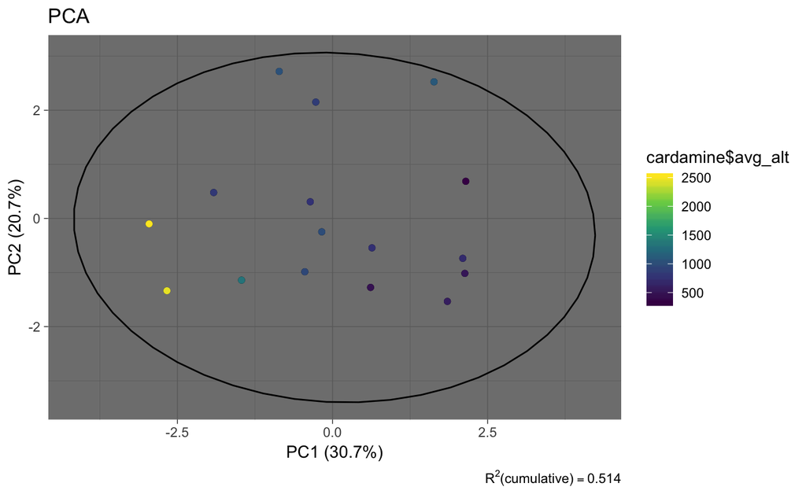

```r
card.pca.data <- get_plotdata(card.pca)
plot_pca(card.pca) +
  geom_point(aes(color = cardamine$avg_alt)) +
  scale_color_viridis_c() +
  theme_dark()
```

# PLSR

```r
opls(cardamine %>% select(Xs), cardamine$avg_alt, plotL = FALSE, printL = FALSE)
```

```
PLS
16 samples x 10 variables and 1 response
standard scaling of predictors and response(s)
9 (5%) NAs
```

|  | R2X(cum) | R2Y(cum) | Q2(cum) | RMSEE | pre | ort | pR2Y | pQ2 |
| --- | --- | --- | --- | --- | --- | --- | --- | --- |
| Total | 0.3 | 0.763 | 0.582 | 317 | 1 | 0 | 0.05 | 0.05 |

Good model! Only one component, so I’ll use OPLS

```
OPLS
16 samples x 10 variables and 1 response
standard scaling of predictors and response(s)
9 (5%) NAs
```

|  | R2X(cum) | R2Y(cum) | Q2(cum) | RMSEE | pre | ort | pR2Y | pQ2 |
| --- | --- | --- | --- | --- | --- | --- | --- | --- |
| Total | 0.484 | 0.957 | 0.729 | 146 | 1 | 2 | 0.05 | 0.05 |

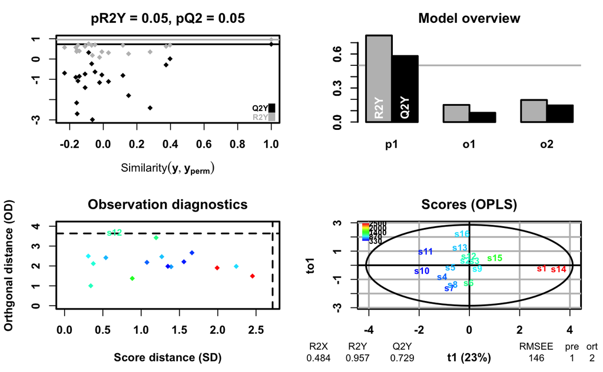

```r
card.opls <- opls(cardamine %>% select(Xs), cardamine$avg_alt, predI = 1, orthoI = NA)
```

```
the condition has length > 1 and only the first element will be usedScale for 'colour' is already present. Adding another scale for 'colour', which will replace the
existing scale.
```

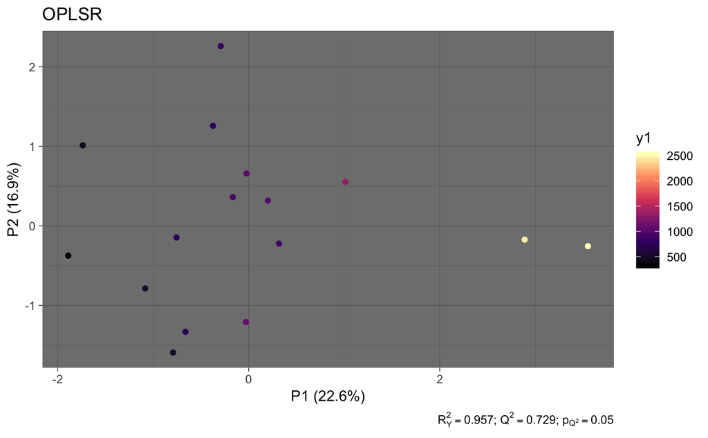

```r
plot_opls(card.opls) + scale_color_viridis_c(option = "A") + theme_dark()
```

# Compare variables

## PCA

```r
card.pca %>%
  get_loadings() %>%
  arrange(desc(abs(p1)))
```

| Variable | p1 | p2 |
| --- | --- | --- |
| gls_c | -0.5204994 | -0.1115869 |
| sla | 0.4144727 | -0.3441995 |
| photosy | -0.4071388 | -0.0661823 |
| height | 0.3798413 | 0.3975972 |
| gls_ja_c | 0.3288809 | -0.1627491 |
| vocs_ja_c | 0.2265942 | -0.2052173 |
| c_n | 0.1805004 | 0.2170527 |
| toughness | -0.1629491 | 0.1463871 |
| voc_c | -0.1410808 | 0.4386226 |
| wight | 0.0933126 | 0.6140677 |

so high altitude (negative on PC1) is associated with high constitutive glucosinolates, low SLA, high chlorophyll mostly

## OPLS

```r
card.opls %>%
  get_VIP() %>%
  arrange(desc(VIP))
```

| Variable | VIP |
| --- | --- |
| gls_c | 1.3649467 |
| height | 1.3642502 |
| sla | 1.3247236 |
| photosy | 1.1833367 |
| gls_ja_c | 1.1311316 |
| vocs_ja_c | 1.0051579 |
| voc_c | 0.6075385 |
| wight | 0.5225382 |
| toughness | 0.3972898 |
| c_n | 0.1754252 |

ehh, lame. pretty much the same conclusion.

# Individual data

I emailed Sergio Rasmann and got the un-summarized data, but it’s confusing.

| species | id | species_2 | treatment | replicate | treatment_nb | leaveas_area_nub | collection_date | x_coord | y_coord | altitude | avg_altitude | altitude_class | av_weight | av_sla | percent_damage | av_height | av_photosynt | av_toughness | weight_mg_cn | nitrogen_percent | carbon_percent | cn | hydrogen_percent | gls_total | gls_c | gls_induced | voc_total | vocs_c | vocs_induced |
| --- | --- | --- | --- | --- | --- | --- | --- | --- | --- | --- | --- | --- | --- | --- | --- | --- | --- | --- | --- | --- | --- | --- | --- | --- | --- | --- | --- | --- | --- |
| alpina | ALP0608C1 | C_alpina | C | 1 | C1 | NA | 6.08 | 672756 | 147683 | 2490 | 2450.2982 | H | 192.0 | 18.998745 | 0.0 | 3.5 | 44.46667 | 32.00000 | 10.15 | 3.294000 | 42.53100 | 12.911658 | 5.967000 | 59.8147781 | 59.8147781 | -11.167523 | 4.478075 | 4.478075 | 4.17264851 |
| alpina | ALP0608C2 | C_alpina | C | 2 | C2 | NA | 6.08 | 672756 | 147683 | 2490 | 2450.2982 | H | 103.0 | 14.941207 | 0.0 | 2.0 | 36.76667 | 30.00000 | 7.90 | 3.633000 | 40.33500 | 11.102395 | 5.580000 | 97.4466809 | 97.4466809 | -48.799426 | 8.591203 | 8.591203 | 0.05952006 |
| alpina | ALP0608C3 | C_alpina | C | 3 | C3 | NA | 6.08 | 672756 | 147683 | 2490 | 2450.2982 | H | 59.0 | 15.868206 | 7.5 | 6.0 | 32.76667 | 72.00000 | 5.55 | 3.447000 | 39.88500 | 11.570931 | 5.439000 | 55.2202735 | 55.2202735 | -6.573018 | 2.974439 | 2.974439 | 5.67628403 |
| alpina | ALP0608C4 | C_alpina | C | 4 | C4 | NA | 6.08 | 672756 | 147683 | 2490 | 2450.2982 | H | 76.0 | 16.024817 | 5.0 | 4.0 | 48.26667 | 60.00000 | 6.39 | 3.368000 | 40.07900 | 11.899941 | 5.586000 | 41.2683990 | 41.2683990 | 7.378856 | 9.113187 | 9.113187 | -0.46246350 |
| alpina | ALP0608JA1 | C_alpina | JA | 1 | JA1 | NA | 6.08 | 672756 | 147683 | 2490 | 2450.2982 | H | 253.0 | 13.339960 | 5.0 | 4.5 | 38.33333 | 62.00000 | 10.44 | 4.742000 | 40.08300 | 8.452763 | 5.766000 | 60.0896602 | NA | NA | 6.536295 | NA | NA |
| alpina | ALP0608JA2 | C_alpina | JA | 2 | JA2 | NA | 6.08 | 672756 | 147683 | 2490 | 2450.2982 | H | 272.0 | 14.310198 | 5.0 | 5.0 | 34.13333 | 30.00000 | 10.25 | 4.374000 | 40.10900 | 9.169867 | 5.643000 | 9.0789214 | NA | NA | 10.191130 | NA | NA |
| alpina | ALP0608JA3 | C_alpina | JA | 3 | JA3 | NA | 6.08 | 672756 | 147683 | 2490 | 2450.2982 | H | 148.0 | 13.904132 | 5.0 | 5.0 | 34.73333 | 20.00000 | 10.01 | 4.267000 | 40.68300 | 9.534333 | 5.784000 | 76.3639120 | NA | NA | 5.262597 | NA | NA |
| alpina | ALP0608JA4 | C_alpina | JA | 4 | JA4 | NA | 6.08 | 672756 | 147683 | 2490 | 2450.2982 | H | 166.0 | 22.513968 | 0.0 | 6.5 | 41.70000 | 54.00000 | 8.68 | 3.573000 | 41.17300 | 11.523370 | 5.700000 | 49.0565276 | NA | NA | 12.612870 | NA | NA |
| amara | AMA0608C1 | C_amara | C | 1 | C1 | NA | 6.08 | 702633 | 150902 | 1490 | 954.1897 | M | 123.0 | 12.460317 | 5.0 | 25.0 | 29.03333 | 43.00000 | 10.26 | 4.892000 | 38.93000 | 7.957890 | 5.643000 | 62.1824063 | 62.1824063 | -16.881030 | 29.160173 | 29.160173 | 137.20406330 |
| amara | AMA0608C2 | C_amara | C | 2 | C2 | NA | 6.08 | 702633 | 150902 | 1490 | 954.1897 | M | 467.0 | 12.323391 | 10.0 | 20.0 | 32.26667 | 54.00000 | 9.86 | 3.986000 | 37.92300 | 9.514049 | 5.644000 | 43.3658601 | 43.3658601 | 1.935516 | 5.279340 | 5.279340 | 161.08489670 |

[output cut: 220 more lines]

- `species`: specific epithet, don’t use–has wrong number of unique values
- `id`: unique plant ID, includes species abbrev., population number, induction treatment, and rep number
- `species_2`: Scientific name
- `treatment`: whether a plant was treated with jasmonic acid (JA) a control plan (C) or NA???
- `replicate`
- `treatment_nb`: don’t use
- `leaveas_area_nub`
- `collection_date`
- `x_coord`
- `y_coord`
- `altitude`: Actual altitude where the plant was collected
- `avg_altitude`: Average altitude of the species from Swiss-wide occurance data
- `altitude_class`: Character representation of altitude, don’t use.
- `av_weight`: weight of each plant
- `av_sla`: specific leaf area (ratio of 6mm diameter leaf disc area to its dry mass ($mm^2/mg$)
- `percent_damage`: ordinal percentage eaten (100% = all leaves gone)
- `av_height`: height of each plant
- `av_photosynt`: Actually chlorophyll content (SPAD)
- `av_toughness`: leaf toughness
- `weight_mg_cn`: sample weight for carbon/nitrogen analysis, ignore
- `nitrogen_percent`: %N content
- `carbon_percent`: %C content
- `cn`: Carbon to nitrogen ratio
- `hydrogen_percent`: ignore
- `gls_total`: glucosinolates in this specific plant
- `gls_c`: glucosinolates in this specific plant for control plants
- `gls_induced`: Mean `gls_total`for JA treated plants in this population - `gls_c`
- `voc_total`: VOCs in this specific plant
- `vocs_C`: VOCs in this specifc plant for control plants
- `vocs_induced`: Mean `voc_total` for JA treated plants in this population (species?) - `vocs_c`

# Is population summary the same as species summary?

Maybe summarizing by population makes sense?

| species_2 | collection_date | n |
| --- | --- | --- |
| C_alpina | 6.08 | 8 |
| C_amara | 6.08 | 8 |
| C_bulbifera | 17.05 | 10 |
| C_flexuosa | 6.05 | 8 |
| C_heptaphylla | 10.06 | 8 |
| C_heptaphylla | 6.05 | 8 |
| C_hirsuta | 5.01 | 8 |
| C_impatiens | 17.05 | 8 |
| C_kitaibelii | 42562 | 8 |
| C_matthioli | 42 012 | 6 |

[output cut: 10 more lines]

Can I recapitulate species summary data??

| species_2 | avg_altitude | av_weight | av_sla | percent_damage | av_height | av_photosynt | av_toughness | cn | gls_c | gls_induced | vocs_c | vocs_induced |
| --- | --- | --- | --- | --- | --- | --- | --- | --- | --- | --- | --- | --- |
| C_alpina | 2450.2982 | 158.6250 | 16.23765 | 3.437500 | 4.56250 | 38.89583 | 45.00000 | 10.770657 | 63.437533 | -14.790278 | 6.289226 | 2.361497 |
| C_amara | 954.1897 | 269.8750 | 14.30764 | 8.750000 | 26.12500 | 28.75208 | 58.25000 | 8.800629 | 53.094942 | -7.793566 | 11.785207 | 154.579030 |
| C_asarifolia | 998.8889 | NA | NA | NA | NA | NA | NA | NA | 44.121381 | NA | 5.931438 | 12.575413 |
| C_bulbifera | 581.0000 | 515.5000 | 55.53945 | 37.500000 | 36.55000 | 33.62333 | 42.26667 | 10.326839 | 26.759116 | 20.490625 | 16.774915 | 114.522399 |
| C_flexuosa | 744.3143 | 696.0000 | 39.54672 | 24.500000 | 25.00000 | 28.20000 | 72.16667 | 15.754643 | 67.178016 | 2.872092 | 24.466448 | 8.203135 |
| C_heptaphylla | 1097.4730 | 2167.0846 | 23.70050 | 10.750000 | 48.75000 | 30.42396 | 72.04167 | 19.921849 | 3.911239 | -3.583801 | 26.809363 | 43.255210 |
| C_hirsuta | 512.4387 | 384.9375 | 49.93837 | 14.375000 | 21.12500 | 17.74375 | 43.85417 | 18.142428 | 9.089331 | -2.289018 | 28.953601 | 276.266296 |
| C_impatiens | 701.1321 | 656.2500 | 45.55033 | 15.500000 | 45.40000 | 33.49000 | 26.26667 | 9.991546 | 9.740776 | 21.924464 | 34.917392 | 166.499522 |
| C_kitaibelii | 860.0513 | 1533.5143 | 13.79874 | 26.250000 | 45.75000 | 25.68542 | 63.33333 | 12.324262 | 47.913712 | -31.239610 | 59.853037 | -6.994475 |
| C_matthioli | 325.5833 | 1130.6667 | 42.18916 | 24.000000 | 59.60000 | 22.64000 | 76.33333 | 11.435545 | 9.195151 | 15.343103 | 7.009297 | -3.760425 |

[output cut: 6 more lines]

```r
cardamine
```

| spp | alt | light | moisture | ph | nutrients | avg_alt | fd_temperature | fd_moisture | fd_radiation | wight | sla | dmage | height | photosy | toughness | pieris | spod | c_n | gls_c | gls_ja | gls_ja_c | nb_peaks | voc_c | voc_ja | vocs_ja_c |
| --- | --- | --- | --- | --- | --- | --- | --- | --- | --- | --- | --- | --- | --- | --- | --- | --- | --- | --- | --- | --- | --- | --- | --- | --- | --- |
| C_alpina | 1.0 | 4 | 4.0 | 2 | 2 | 2450.2982 | 681.2931 | 678.775862 | 24673.19 | 158.6250 | 16.23765 | 3.437500 | 4.56250 | 38.89583 | 45.00000 | NA | NA | 10.583035 | 68.176942 | 46.6989620 | -21.47798020 | 13 | 0.1533958 | 0.2109932 | 0.05759749 |
| C_amara | 2.0 | 4 | 5.0 | 3 | 3 | 954.1897 | 2226.8375 | -147.243750 | 26627.30 | 269.8750 | 14.30764 | 8.750000 | 26.12500 | 28.75208 | 61.62500 | 2.751619 | 0.2017750 | 8.729169 | 44.600563 | 44.5132426 | -0.08732079 | 7 | 0.2874441 | 4.0576643 | 3.77022025 |
| C_asarifolia | 2.0 | 4 | 5.0 | 2 | 3 | 998.8889 | 2141.5000 | -264.611111 | 26309.28 | NA | NA | NA | NA | NA | NA | NA | NA | NA | 44.121381 | NA | NA | NA | 0.2578886 | 0.8046457 | 0.54675711 |
| C_bulbifera | 3.5 | 2 | 3.5 | 3 | 4 | 581.0000 | 2506.1000 | 0.450000 | 27535.20 | 515.5000 | 55.53945 | 37.500000 | 36.55000 | 33.62333 | 42.26667 | NA | NA | 10.283131 | 27.569590 | 47.7936768 | 20.22408679 | 8 | 0.4091443 | 3.2023735 | 2.79322925 |
| C_flexuosa | 3.5 | 3 | 4.5 | 3 | 3 | 744.3143 | 2250.2143 | 7.511905 | 26251.69 | 696.0000 | 39.54672 | 24.500000 | 25.00000 | 28.20000 | 72.16667 | 6.297381 | 0.4639274 | 15.338700 | 49.997896 | 70.2034299 | 20.20553426 | 8 | 0.5967426 | 0.6374553 | 0.04071264 |
| C_heptaphylla | 3.5 | 3 | 4.0 | 3 | 4 | 1097.4730 | 1892.8062 | 230.693798 | 24334.64 | 2167.0846 | 23.70050 | 10.750000 | 48.75000 | 30.42396 | 72.04167 | NA | NA | 19.640165 | 6.425146 | 0.5270359 | -5.89811058 | 10 | 0.6538869 | 1.7088920 | 1.05500512 |
| C_hirsuta | 3.0 | 2 | 3.5 | 4 | 4 | 512.4387 | 2424.2668 | -76.728081 | 27315.54 | 384.9375 | 49.93837 | 14.375000 | 21.12500 | 17.74375 | 43.85417 | 4.271000 | 0.0927641 | 17.598529 | 23.196559 | 16.9793109 | -6.21724817 | 9 | 0.7061854 | 7.4443877 | 6.73820234 |
| C_impatiens | 3.5 | 4 | 3.0 | 3 | 4 | 701.1321 | 2449.7692 | -135.935897 | 26362.31 | 656.2500 | 45.55033 | 15.500000 | 45.40000 | 33.49000 | 26.26667 | 8.053655 | 0.5665583 | 9.923319 | 15.473200 | 31.7551787 | 16.28197866 | 10 | 0.8516437 | 4.9126077 | 4.06096394 |
| C_kitaibelii | 3.5 | 3 | 3.5 | 3 | 4 | 860.0513 | 2316.3095 | 497.214286 | 21691.52 | 1533.5143 | 13.79874 | 26.250000 | 45.75000 | 25.68542 | 63.33333 | NA | NA | 12.266507 | 40.446229 | 30.6165078 | -9.82972096 | 5 | 1.4598302 | 1.0313866 | -0.42844360 |
| C_matthioli | 3.5 | 2 | 3.0 | 4 | 4 | 325.5833 | 3168.7500 | 280.113636 | 26774.36 | 1130.6667 | 42.18916 | 24.000000 | 59.60000 | 22.64000 | 76.33333 | NA | NA | 11.283793 | 12.299083 | 13.5618568 | 1.26277386 | 6 | 0.3047520 | 0.1412553 | -0.16349673 |

[output cut: 6 more lines]

VOCs and glucosinolate numbers are super different and I don’t know why. C/N is slightly different. Toughness also slightly different.

```r
opls(recap %>% select(av_weight, av_sla, av_toughness, av_height, av_photosynt, cn, gls_c, gls_induced, vocs_c, vocs_induced), recap$avg_altitude, predI = 1, orthoI = NA, plotL = FALSE, printL = FALSE)
```

```
OPLS
16 samples x 10 variables and 1 response
standard scaling of predictors and response(s)
11 (6%) NAs
```

|  | R2X(cum) | R2Y(cum) | Q2(cum) | RMSEE | pre | ort | pR2Y | pQ2 |
| --- | --- | --- | --- | --- | --- | --- | --- | --- |
| Total | 0.521 | 0.884 | 0.55 | 240 | 1 | 2 | 0.1 | 0.05 |

Woah, pls is way worse

# Population level data

Let’s try for population level data

## Population level PCA

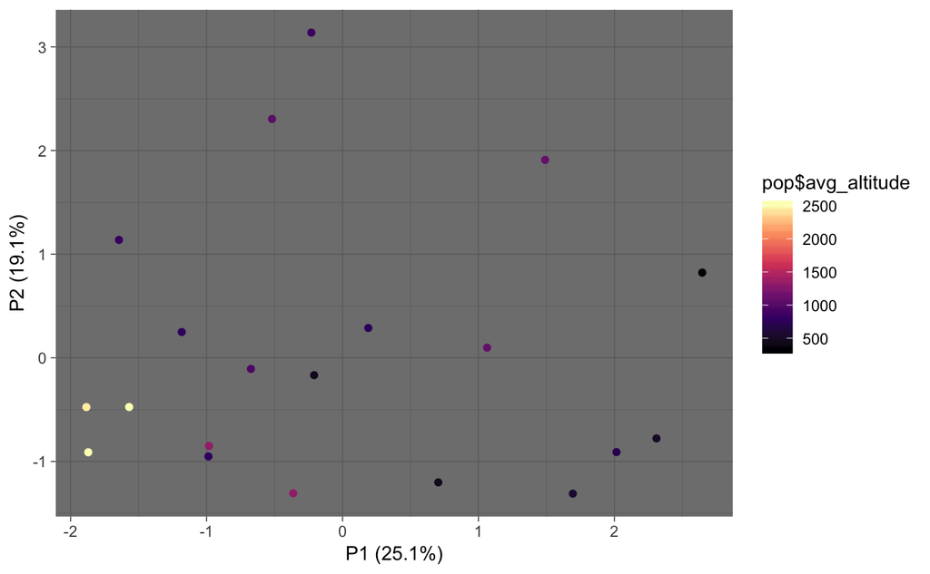

```
the condition has length > 1 and only the first element will be usedScale for 'colour' is already present. Adding another scale for 'colour', which will replace the
existing scale.
```

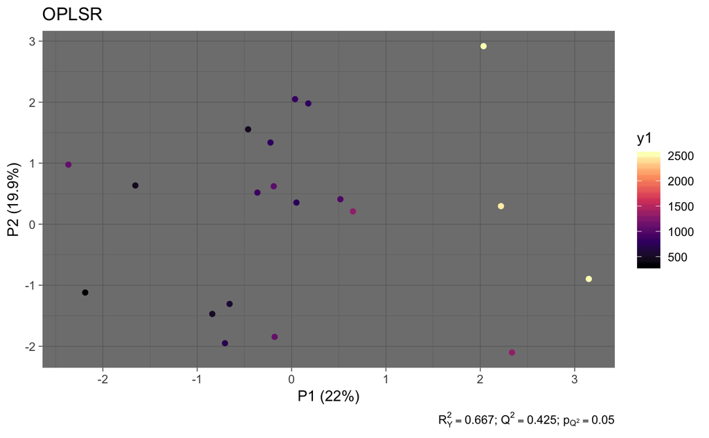

```r
plot_opls(pop.opls) + scale_color_viridis_c(option = "A") + theme_dark()
```

[output not shown]